# MATP-4910 COVID-19 Final Project Notebook

MORTALITYMINDER

Jocelyn McConnon

15 December 2020

## Final Project: Submission Links

- github repository: https://github.com/TheRensselaerIDEA/COVIDMINDER
- github branch: darl-mcconj2
- github ID: jocelynmcconnon-bot
- draft final notebook: https://htmlpreview.github.io/?https://raw.githubusercontent.com/TheRensselaerIDEA/COVIDMINDER/master/DARL-2020-Notebooks/darl_mcconj2_final.html

## Overview & Problems Tackled

I used the MortalityMinder app to investigate the causes of midlife mortality in the American Southwest region, specifically in Sierra County, New Mexico. I summarized the results of my finding in the paper “Investigating Social Determinants of Premature Mortality in the United States”. I worked to bring this paper into JAMIA format, and created a presentation version as well.

## Data Description

All of the data I used came from the MortalityMinder app, which is simply a visualization tool for the mortality rates by county as reported by the CDC. MortalityMinder uses k-means clustering to partition each county into a risk group for each respective cause of midlife death. The risk groups are low, medium, and high. The causes of midlife mortality that are considered are deaths of despair, cardiovascular disease, cancer, and all causes.

## Results

Since the problem I was addressing in my research was crafting use cases for the MortalityMinder app, to be used in the results section of the paper, I will address the use cases I researched below.

## Sierra County, New Mexico: county level health care provider

In the first use case I will discuss, I looked at MortalityMinder from the point of view of a healthcare provider. This would be someone who would be interested in understanding how and why people are dying at the county level, and the social determinant factors that have a destructive impact on the mortality rate. This is just one use in which the app may provide meaningful insight.

Sierra County, New Mexico is one of the worst effected places in the country, experiencing extremely high rates of midlife mortality. The rates of all cause, cancer, cardiovascular disease, and deaths of despair are all way above the national averages.

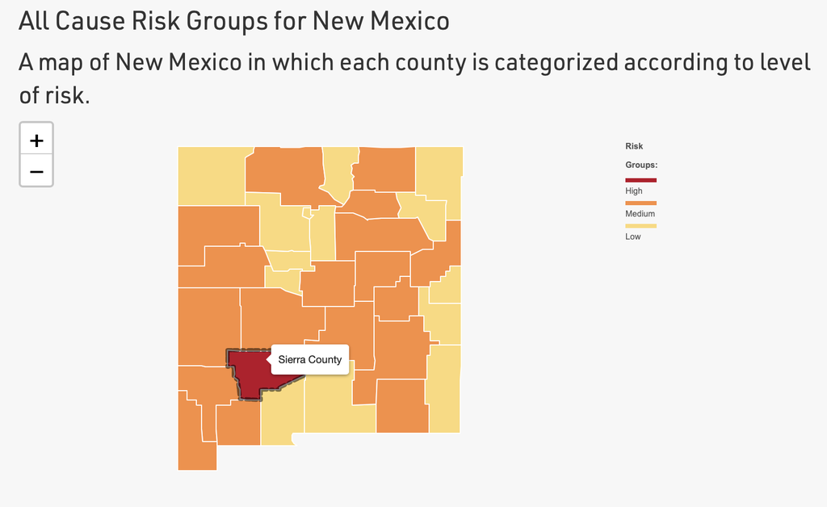

Figure 1. Sierra County is the singular high risk county.

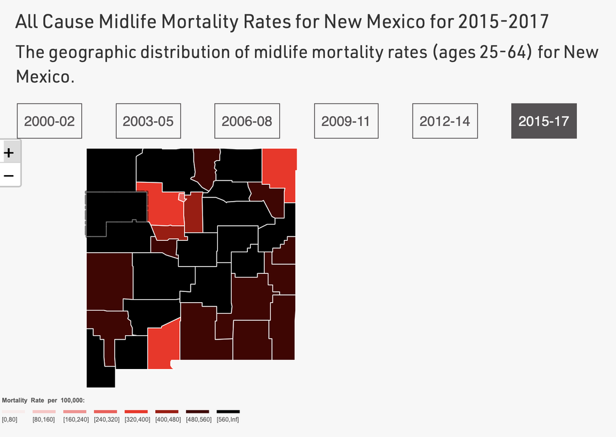

Since MortalityMinder is a data visualization tool for health care researchers, providers, payers, and policy makers, I narrowed down the scope of the use case to only the utility it could provide to health care providers in this local.

The leading factors associated with all causes of midlife mortality are children in poverty, free lunch, socio-economic status, mentally unhealthy days, fair or poor health, physically unhealthy days, single parent households, frequent mental distress, frequent physical distress, and income ratio.

From the point of view of a health care provider, this information may be useful to understand what efforts would most positively impact the community.

For example, factors such as fair or poor health and physically unhealthy days are destructive determinants of mortality. Therefore, increasing access to physical activities (like offering yoga classes or swimming lessons at the local hospital) may be something that would have an impact on the midlife mortality rates.

MortalityMinder can provide context to what is contributing to all causes of midlife mortality in Sierra County. For example, in 2015-2017, the rate of all causes of midlife mortality per 100,000 deaths was 1100. Of that, roughly 150 were deaths of despair, 200 were due to cancer, and 250 were due to cardiovascular disease. So, the three named causes account for around half of the midlife deaths.

The social determinants that positively correlated with more than one of the three named causes of midlife mortality are single parent households (destructive determinate of deaths of despair and cancer) mental health provider rate (destructive determinate of deaths of despair and cardiovascular disease) teen birth rate (destructive determinant of cardiovascular disease and cancer), and primary care physicians ratio (destructive determinant of cardiovascular disease and cancer).

## New Mexico: state level policy maker

The next use case I will discuss is from the point of view of a state level policy maker. This is an individual who would also be interested in knowing how and why people are dying prematurely, but also where geographically is the most affected by each cause of death.

As previously discussed, Sierra County is the singular high risk county for all causes of midlife mortality. Sierra County and De Baca County compose the high risk group for midlife deaths due to cancer, and the high risk group for cardiovascular disease. A total of four counties are in the high risk group for deaths of despair- Sierra County, Rio Arriba, San Miguel, and Quay County.

New Mexico, as a whole, is one of the worst places in the country when it comes to premature midlife death.

The mortality rate due to deaths of despair has increased 53.3% from 2000 to 2017, and the rate due to all causes of midlife death increased 25.6%.

Interestingly, the rates of deaths due to cancer and cardiovascular disease decreased in the same time period.

From the point of view of a state level policy maker, it would seem that addressing deaths due to despair would be a priority- considering both the rapidly increasing rates and the fact that four counties are in the high risk group.

The leading factors associated with deaths of despair are single parent households, low birthweight, violent crime rate, female, mental health provider rate, socio-economic status, and other primary care rate.

While factors such as “female” cannot be addressed at the policy level, other factors such as mental health provider rate and primary care rate easily can and should be.

Access to mental health and primary care physicians should be an urgent concern to policy makers. One suggestion I have is to institute wage compensation for professionals in these fields who are willing to relocate to NM.

This is just one example of insights from MortalityMinder that could be used to implement policy changes that would address the underlying issues associated with deaths of despair.

## Summary and Recommendations

I think that the story of midlife mortality in New Mexico, especially deaths of despair, is a compelling one.

Not only that, but looking at how MortalityMinder can be used to understand the factors leading to premature death is crucial to addressing the problem.

My research into the leading factors associated with deaths of despair suggested that there was a shortage in primary care and mental health providers.

In a recent opinion piece, Andy Winnegar shared his struggle to find a primary care physician after his announced they would be going into retirement. I thought it was relevant to our discussion to share a quote of his (found in Figure 3 in the Appendix) where he argues that the low pay of doctors in New Mexico might explain their shortage.

In the news, I found a press release from a New Mexico congressional delegation representative that discussed the funding of the health care system in Sierra County for the treatment, prevention, and recovery efforts in response to the opioid epidemic. This is relevant to our discussion because deaths of despair encompass deaths due to overdose and substance abuse.

While I have briefly gone over what I found and the main take aways of my contributions to the paper, I think that this aspect of the results is an important one.

Other aspects of the analysis include looking at the factors between states of similar population sizes, and national trends in deaths of despair.

One recommendation that I have for the application of MortalityMinder in the future is an inclusion of “deaths due to COVID” as a cause of premature midlife death. This would be in MortalityMinder (not CovidMinder) and include the same k-means clustering and analysis of social determinants using Kendell correlation value.

These features already exist in CovidMinder, but I’m simply recommending that they are also included in MortalityMinder since I’m willing to bet that Coronavirus will continue to be a killer for the next couple years.

## References

Weinnegar, Andy. (2020, September 12). “Difficulties of finding a primary care doctor”. Senta Fe New Mexican. https://www.santafenewmexican.com/life/family/difficulties-of-finding-a-primary-care-doctor/article_9692e624-dd93-11ea-ae9e-bfa19b7231a8.html. Accessed on 2020, October 19.

Haaland, Deb. (2019, May 30). “New Mexico Delegation Announces $600,000 to combat opioid epidemic in rural communities”. Deb Haaland. https://haaland.house.gov/media/press-releases/new-mexico-delegation-announces-600000-combat-opioid-epidemic-rural-communities. Accessed on 2020, October 19.

## Appendix

[figure not shown]

Figure 3. Opinion piece by Andy Winnegar in the Senta Fe New Mexican

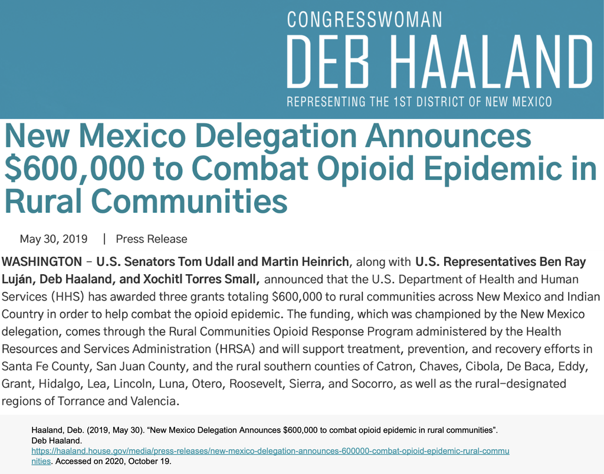

Figure 4. Press release by Deb Haaland regarding healthcare funding